# Welcome to Lab 1 – Registration and Introduction to the Lab

**Import the necessary libraries:**

```python
%matplotlib inline
import numpy as np
import matplotlib.pylab as plt
from skimage import color
from skimage import img_as_ubyte
```

**Now you need to write your code:**

1. Load your image in Python using imread function, use:

   ```
   my_img = plt.imread('my_image.bmp')
   plt.imshow(my_img)
   plt.show()
   ```

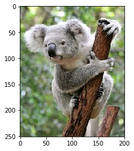

```python
my_img = plt.imread('koala.bmp')
plt.imshow(my_img)
plt.show()
```

1. Note the data type and values of your image, use:

   ```
   my_img.dtype
   my_img.shape
   ```

   and print the results

```python
print(my_img.dtype)
print(my_img.shape)
```

```
uint8
(251, 201, 3)
```

1. Study the **color.rgb2gray(image)** function, notice the **cmap** argument and it's default value.
   - Use *color.rgb2gray(image)* on your image and show the grayscale image
   - Use *image.shape* to determine the image dimensions. print the result
   - Noticed if the type was change? print the image type

```python
my_gray_img=color.rgb2gray(my_img)
plt.imshow(my_gray_img, cmap='gray')
plt.show()
print(my_gray_img.shape)
print(my_gray_img.dtype)
```

[output not shown]

```
(251, 201)
float64
```

- How can we use the matrix dimensions to see if our image is in grayscale?

When the image has 2 dimensions (x and y only) we know that there is only 1 color dimension and therfore the image is grayscale

1. Notice the minimum and maximum values of the matrix (the gray image), use:

   ```
   np.max
   np.min
   ```

```python
print('max value= {0}\n min value={1}'.format(np.max(my_gray_img),np.min(my_gray_img)))
```

```
max value= 1.0
 min value=0.0
```

1. Display the image using imshow. Read about imshow from the following [link](https://matplotlib.org/api/_as_gen/matplotlib.pyplot.imshow.html) or Help section, and observe the differences between the following:

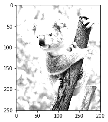

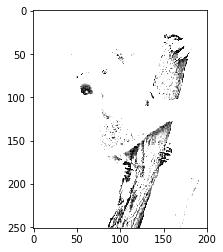

```python
plt.imshow(my_gray_img, cmap = 'gray')
plt.show()
plt.imshow(my_gray_img,vmin=0, vmax=1,cmap = 'gray')
plt.show()
plt.imshow(my_gray_img,vmin=0, vmax=0.5,cmap = 'gray')
plt.show()
plt.imshow(my_gray_img,vmin=0, vmax=0.2,cmap = 'gray')
plt.show()
```

[output not shown]

1. Save the gray image to a png file in your folder, use:

   ```
   plt.imsave()
   ```

```python
plt.imsave("C:\\Users\\iplab_5\\Desktop\\lab1\\gray_koala.png",my_gray_img, cmap = 'gray')
```

1. Save the image to a different file and format (jpg).

```python
plt.imsave("C:\\Users\\iplab_5\\Desktop\\lab1\\gray_koala_jpg.jpg",my_gray_img, cmap = 'gray')
```

1. Now we will change the image type from float to uint8 and repeat section 5.
   - What is the default behavior of the function for each data type?
   - What is the difference between using np.array(image, dtype=np.uint8) and img_as_ubyte(image)?

```
[[0.46894667 0.50229137 0.51181608 ... 0.70469961 0.72348902 0.71285529]
 [0.41853176 0.46559059 0.49641255 ... 0.67556706 0.6904349  0.69465412]
 [0.36502863 0.42777373 0.48521333 ... 0.6587498  0.67782196 0.69212431]
 ...
 [0.33643882 0.34820353 0.3638898  ... 0.54209373 0.47878314 0.43172431]
 [0.36249098 0.37425569 0.38994196 ... 0.50679961 0.44405451 0.4322898 ]
 [0.3854549  0.39721961 0.41290588 ... 0.46142235 0.39699569 0.42722941]]
image = np.array(my_gray_img, dtype=np.uint8):
[[0 0 0 ... 0 0 0]
 [0 0 0 ... 0 0 0]
 [0 0 0 ... 0 0 0]
 ...
 [0 0 0 ... 0 0 0]
 [0 0 0 ... 0 0 0]
 [0 0 0 ... 0 0 0]]
uint8
```

```
im_uint8 =img_as_ubyte(im_gray):
[[120 128 131 ... 180 184 182]
 [107 119 127 ... 172 176 177]
 [ 93 109 124 ... 168 173 176]
 ...
 [ 86  89  93 ... 138 122 110]
 [ 92  95  99 ... 129 113 110]
 [ 98 101 105 ... 118 101 109]]
uint8
```

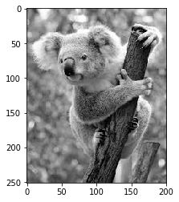

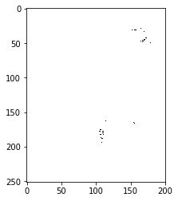

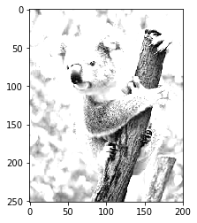

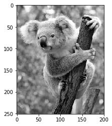

```python
print(my_gray_img)

image = np.array(my_gray_img, dtype=np.uint8) #convert image to uint8
print("image = np.array(my_gray_img, dtype=np.uint8):")
print(image)
print(image.dtype)

plt.imshow(image,  cmap = 'gray')
plt.show()
plt.imshow(image,vmin=0, vmax=1, cmap = 'gray')
plt.show()
plt.imshow(image,vmin=0, vmax=0.5, cmap = 'gray')
plt.show()
plt.imshow(image,vmin=0, vmax=0.2, cmap = 'gray')
plt.show()

im_uint8 = img_as_ubyte(my_gray_img) #ubyte
print("\nim_uint8 =img_as_ubyte(im_gray):")
print(im_uint8)
print(im_uint8.dtype)

plt.imshow(im_uint8, cmap = 'gray')
plt.show()
plt.imshow(im_uint8,vmin=0, vmax=1, cmap = 'gray')
plt.show()
plt.imshow(im_uint8,vmin=0, vmax=125, cmap = 'gray')
plt.show()
plt.imshow(im_uint8,vmin=0, vmax=255, cmap = 'gray')
plt.show()
```

[output not shown]

Write your observation of the different function here:

uint8 - the type conversation lacks rescaling - it rounds all the values to 0 and 1 and the result is a black image ubyte - convert to a value [0,255] with proper rescaling. The image is clearly seen.

1. Crop the upper-left 100×100 block of your image. Crop another 100×100 block from the bottom-right part of the image.

   Hold the 2 blocks in new uint8 variables: B1 and B2. Display the two sections using imshow.

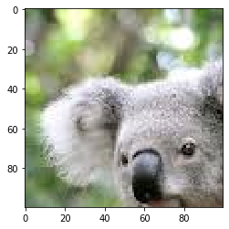

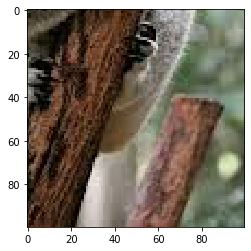

```python
B1=my_img[0:100,0:100]
B1 = img_as_ubyte(B1)
B1.shape
plt.imshow(B1)
plt.show()

[n,m,colors]=my_img.shape
B2=my_img[n-100:n,m-100:m]
B2 = img_as_ubyte(B2)
B2.shape
plt.imshow(B2)
plt.show()
```

### **Now save your results and your notebook and go back to lab 1 Manual**